# nlp_movies-part1

There are other popular python packages for Natural Language processing including spaCy: https://spacy.io/ but we will focus primarily on NLTK.

NLTK is a popular Python package for NLP that provides a suite of text processing libraries for classification, tokenization, stemming, tagging, parsing, and semantic reasoning. It also contains interfaces to over 50 corpora and lexical resources such as WordNet.

It includes many easy-to-use datasets in the nltk.corpus package. We can download the movie_reviews package using the nltk.download function:

- nltk.download("movie_reviews")

We can also list and download other datasets interactively:

- nltk.download()

Once the data have been downloaded, we can import them from nltk.corpus

- from nltk.corpus import movie_reviews

### Investigsting movie_reviews

```python
import nltk
from  nltk.corpus import movie_reviews
```

fileids provided by all nltk datasets in nltk.corpus gives access to a list of all files available in the corpus

```python
reviews = movie_reviews.fileids()

print('movie reviews files: ', len(reviews))

# top 5
print('\nfirst 5 files:\n', reviews [:5])

# bottom 5
print('\nbottom 5 files:\n', reviews[-5:])

# category of movie
movie_reviews.categories()
```

```
movie reviews files:  2000

first 5 files:
 ['neg/cv000_29416.txt', 'neg/cv001_19502.txt', 'neg/cv002_17424.txt', 'neg/cv003_12683.txt', 'neg/cv004_12641.txt']

bottom 5 files:
 ['pos/cv995_21821.txt', 'pos/cv996_11592.txt', 'pos/cv997_5046.txt', 'pos/cv998_14111.txt', 'pos/cv999_13106.txt']
```

```
['neg', 'pos']
```

the movie_reviews dataset has 2000 text files, each of which is a review of a movie, that are split in a neg folder for the negative reviews and a pos folder for the positive reviews

fileids can also filter the files based on their category (the name of the subfolders they are located in)

```python
negative_files = movie_reviews.fileids('neg')
positive_files = movie_reviews.fileids('pos')

print(f' neg len: {len(negative_files)}\n pos len: {len(positive_files)}')
```

```
 neg len: 1000
 pos len: 1000
```

We can look at the number of words and sentences in the corpus, and for a particular review

```python
first = 'neg/cv000_29416.txt' # first review in the list

# how many words and sentences in the entire move_reviews corpus?
print('all words len:', len(movie_reviews.words()))
print('all sentences len:', len(movie_reviews.sents()))

# how many words in the first review?
print('first review word len:', len(movie_reviews.words(first)))

# how many sentences in the first review?
first_review = movie_reviews.sents(first)
print('first review sentences length:', len(first_review))
```

```
all words len: 1583820
all sentences len: 71532
first review word len: 879
first review sentences length: 44
```

We can also inspect one of the reviews using the raw method of movie_reviews

```python
print('number of chars :', len(movie_reviews.raw(fileids=first)))

review_text = movie_reviews.raw(fileids=first)
review_text
```

```
number of chars : 4043
```

```
'plot : two teen couples go to a church party , drink and then drive . \nthey get into an accident . \none of the guys dies , but his girlfriend continues to see him in her life , and has nightmares . \nwhat\'s the deal ? \nwatch the movie and " sorta " find out . . . \ncritique : a mind-fuck movie …
```

### Tokenize

The first step in Natural Language processing is generally to split the text into tokens (sentences and words)

- text can be split into sentences using sent_tokenize()
- sentence can be split into words using the method word_tokenize(). Note: Special characters are treated as separate tokens

**sentence tokenization**

```python
from nltk.tokenize import sent_tokenize

tokenized_sent = sent_tokenize(review_text)
print('number of sentences in review:', len(tokenized_sent))

print('first 10 sentences')
tokenized_sent[:10]
```

```
number of sentences in review: 44
first 10 sentences
```

```
['plot : two teen couples go to a church party , drink and then drive .',
 'they get into an accident .',
 'one of the guys dies , but his girlfriend continues to see him in her life , and has nightmares .',
 "what's the deal ?",
 'watch the movie and " sorta " find out .',
 '.',
 '.',
 'critique : a mind-fuck movie for the teen generation that touches on a very cool idea , but presents it in a very bad package .',
 "which is what makes this review an even harder one to write , since i generally applaud films which attempt to break the mold , mess with your head and such ( lost highway & memento ) , but there are good and bad ways of making all types of films , and these folks just didn't snag this one correct…
 'they seem to have taken this pretty neat concept , but executed it terribly .']
```

Noticed .. was treated as a sentence. Sentence segmentation is difficult because period is used to mark abbreviations, and some periods simultaneously mark an abbreviation and terminate a sentence, as often happens with acronyms like U.S.A.

For another approach to sentence segmentation, see 6.2: http://www.nltk.org/book_1ed/ch06.html#sec-further-examples-of-supervised-classification

**word tokenization**

```python
from nltk.tokenize import word_tokenize

tokenized_word = word_tokenize(review_text)
print('number of words in review:', len(tokenized_word))

print('first 15 word tokens')
tokenized_word[:15]
```

```
number of words in review: 841
first 15 word tokens
```

```
['plot',
 ':',
 'two',
 'teen',
 'couples',
 'go',
 'to',
 'a',
 'church',
 'party',
 ',',
 'drink',
 'and',
 'then',
 'drive']
```

Most of these tokens are words but we do see punctuation is treated as a token also. We also see some very common words such as a, and, etc..

### Word Frequency

A frequency distribution records the number of times each outcome of an experiment has occurred. For example, a frequency distribution could be used to record the frequency of each word type in a document.

- Find frequency of each word using FreqDist package

```python
from nltk.probability import FreqDist

fdist = FreqDist(tokenized_word)
fdist
```

```
FreqDist({',': 44, 'the': 38, '.': 34, 'it': 25, 'and': 20, 'to': 16, 'of': 16, 'a': 14, 'that': 13, 'are': 13, ...})
```

Notice that punctuation and high frequency stop words are included.

**Next show top 10 most common words**

```python
fdist.most_common(10)
```

```
[(',', 44),
 ('the', 38),
 ('.', 34),
 ('it', 25),
 ('and', 20),
 ('to', 16),
 ('of', 16),
 ('a', 14),
 ('that', 13),
 ('are', 13)]
```

## Preprocessing

The process of converting data to something a computer can understand is referred to as pre-processing. One of the major forms of pre-processing is to filter out useless data, such as stop words.

### Remove stop words

Stop words are high frequency, commonly used words (“the”, “a”, “an”, “in”, etc), we would not want taking up database space or processing time. For example, search engines are programmed to ignore such words, both when indexing entries for search and search queries.  
Why should we remove stop words?

- reducing the size of the data file. (20-30%) of stopwords present in total word counts
- stop words are useless in text mining or in the searching process
- efficiency is increased

We can remove stop words by storing a list of words considered to be stop words. NLTK also includes a list of stopwords stored in 16 different languages.

```python
from nltk.corpus import stopwords
import string

# create a list of english stop words from NLTK, including punctuation
useless_words = stopwords.words("english") + list(string.punctuation)

# filter out the stop words
filtered_words = [word for word in tokenized_word if not word in useless_words]

print('number of words in review after stop words removal:', len(filtered_words))

print('first 15 words')
filtered_words [:15]
```

```
number of words in review after stop words removal: 358
first 15 words
```

```
['plot',
 'two',
 'teen',
 'couples',
 'go',
 'church',
 'party',
 'drink',
 'drive',
 'get',
 'accident',
 'one',
 'guys',
 'dies',
 'girlfriend']
```

We observe that the number of words is much less now. Further, common words such as (a, to, and, etc..) have been removed

### Frequent words excluding stop words

- Plot Top 10 most frequent words
- Graph frequent words

```python
fdist = FreqDist(filtered_words)
fdist.most_common(10)
```

```
[('``', 10),
 ("'s", 9),
 ('movie', 6),
 ("n't", 6),
 ('film', 6),
 ('pretty', 5),
 ('make', 5),
 ('teen', 4),
 ('get', 3),
 ('one', 3)]
```

We can see some of the tokens are still not words. This would require further processing

**plot the top 20 words**

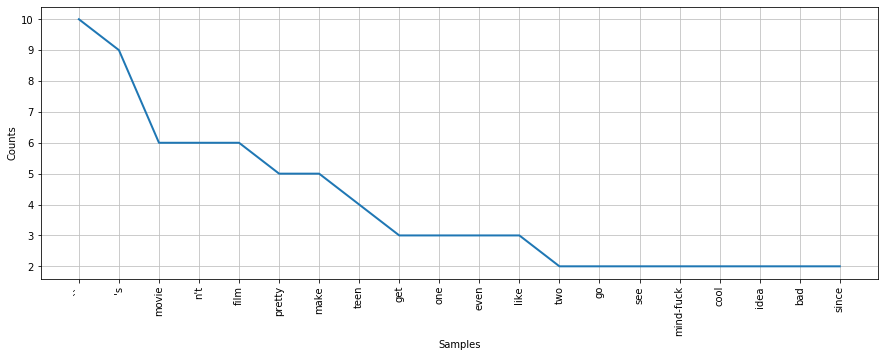

```python
import matplotlib.pyplot as plt

plt.figure(figsize=(15, 5))

fdist.plot(20, cumulative=False)
plt.show();
```

### Stemming and Lemmatization

Stemming and lemmatization are text normalizing procedures used in NLP during text preprocessing. They are widely used in tagging systems, indexing, SEOs, Web search results, and information retrieval. For example, searching for fish on Google will also result in fishes, fishing as fish is the stem of both words. Stemming and Lemmatization attempts to find the root forms (sometimes called synonyms in search context) of inflected (derived) words. However, each is different in its approach.

**Stemming** is a process that reduces words to their word root word (chops off the derivational affixes). Example: connection, connected, connecting are reduced to a common word "connect".

**Lemmatization** reduces words to their base word, with linguistically correct lemmas. Lemmatization is more sophisticated than stemming as it transforms root word with the use of a vocabulary. While Stemmer works on words without knowledge of the context, Lemitation requires a dictionary. Example: "better" has "good" as its lemma which will be missed by stemming.

### Stemming

- for English we can choose between PorterStammer or LancasterStammer
- using the Porter stemming algorithm

```python
from nltk.stem import PorterStemmer

ps = PorterStemmer()

# apply the stemmer to our words list
stemmed_words=[]
for w in filtered_words:
    stemmed_words.append(ps.stem(w))

# create a list of orginal words and stemmed words for comparison
stemmed_list =[]
for w1, w2 in zip(filtered_words, stemmed_words):
    if w1 != w2:
        stemmed_list.append((w1,w2))

print("Filtered Sentences word count:", len(filtered_words))
print("Stemmed Sentences word count:", len(stemmed_list))

# see how words were stemmed
print('\n first 20 stemmed words:')
stemmed_list[:20]
```

```
Filtered Sentences word count: 358
Stemmed Sentences word count: 147

 first 20 stemmed words:
```

```
[('couples', 'coupl'),
 ('party', 'parti'),
 ('accident', 'accid'),
 ('guys', 'guy'),
 ('dies', 'die'),
 ('continues', 'continu'),
 ('nightmares', 'nightmar'),
 ('movie', 'movi'),
 ('critique', 'critiqu'),
 ('movie', 'movi'),
 ('generation', 'gener'),
 ('touches', 'touch'),
 ('presents', 'present'),
 ('package', 'packag'),
 ('makes', 'make'),
 ('since', 'sinc'),
 ('generally', 'gener'),
 ('films', 'film'),
 ('ways', 'way'),
 ('making', 'make')]
```

### Lemmatization

- Lemmatization reduces the inflected words properly ensuring that the root word (lemma) belongs to the language
- NLTK provides WordNet Lemmatizer that uses the WordNet Database to lookup lemmas of words.
- lemmatize takes a part of speech parameter, “pos” (parts of speech). If not supplied, the default is “noun.”

**Verb pos**

```python
from nltk.stem.wordnet import WordNetLemmatizer

lem = WordNetLemmatizer()

# apply the lemmatization to our words list
lemm_words=[]
for w in filtered_words:
    lemm_words.append(lem.lemmatize(w, 'v')) # use verb as pos

# create a list of orginal words and stemmed words for comparison
lemm_list =[]
for w1, w2 in zip(filtered_words, lemm_words):
    if w1 != w2:
        lemm_list.append((w1,w2))

print("Filtered Sentences word count:", len(filtered_words))
print("Lemmatized Sentences word count:", len(lemm_list))

print('\n First 20 Lemmatized words:')
lemm_list[:20]
```

```
Filtered Sentences word count: 358
Lemmatized Sentences word count: 65

 First 20 Lemmatized words:
```

```
[('couples', 'couple'),
 ('guys', 'guy'),
 ('dies', 'die'),
 ('continues', 'continue'),
 ('touches', 'touch'),
 ('presents', 'present'),
 ('makes', 'make'),
 ('films', 'film'),
 ('lost', 'lose'),
 ('making', 'make'),
 ('types', 'type'),
 ('films', 'film'),
 ('taken', 'take'),
 ('executed', 'execute'),
 ('jumbled', 'jumble'),
 ('starts', 'start'),
 ('going', 'go'),
 ('dreams', 'dream'),
 ('characters', 'character'),
 ('coming', 'come')]
```

**Noun pos**

```python
lemm_words=[]
for w in filtered_words:
    lemm_words.append(lem.lemmatize(w, 'n')) # use noun as pos

# create a list of orginal words and stemmed words for comparison
lemm_list =[]
for w1, w2 in zip(filtered_words, lemm_words):
    if w1 != w2:
        lemm_list.append((w1,w2))

print("Filtered Sentences word count:", len(filtered_words))
print("Lemmatized Sentences word count:", len(lemm_list))

print('\n First 20 Lemmatized words:')
lemm_list[:20]
```

```
Filtered Sentences word count: 358
Lemmatized Sentences word count: 39

 First 20 Lemmatized words:
```

```
[('couples', 'couple'),
 ('guys', 'guy'),
 ('dies', 'dy'),
 ('nightmares', 'nightmare'),
 ('touches', 'touch'),
 ('presents', 'present'),
 ('makes', 'make'),
 ('films', 'film'),
 ('ways', 'way'),
 ('types', 'type'),
 ('films', 'film'),
 ('folks', 'folk'),
 ('problems', 'problem'),
 ('starts', 'start'),
 ('downshifts', 'downshift'),
 ('dreams', 'dream'),
 ('characters', 'character'),
 ('apparitions', 'apparition'),
 ('disappearances', 'disappearance'),
 ('scenes', 'scene')]
```

### NER ( Named Entity Recognition)

NER is an NLP task used to identify important named entities in the text such as people, places, organizations, date, monetary values, percentages, etc. It is the first step towards IE (information extraction ) and can be used to help answer real world questions such as: Which companies or products were mentioned in reviews or who is mentioned in social media.

- The first step is to tokenize the text into sentences.
- The next step is Parts of Speech (POS) Tagging.  
  The goal is to identify the grammatical group of a given word. (eg: NOUN, PRONOUN, ADJECTIVE, VERB, ADVERBS, etc.) based on the context. POS Tagging looks for relationships within the sentence and assigns a corresponding tag to the word.

**Some common abbreviations for POS**

- DT: determiner
- IN: preposition/subordinating conjunction
- JJ: adjective ‘big’
- JJR: adjective, comparative ‘bigger’
- JJS: adjective, superlative ‘biggest’
- LS: list marker
- NN: noun, singular ‘desk’
- NNS: noun plural ‘desks’
- NNP: proper noun, singular ‘Harrison’
- NNPS: proper noun, plural ‘Americans’
- PRP: personal pronoun I, he, she
- RB: adverb very, silently,
- UH: interjection
- VB: verb, base form take
- VBD: verb, past tense took

**Commonly Used Types of Named Entity**

```
ORGANIZATION    Georgia-Pacific Corp., WHO
PERSON          Eddy Bonte, President Obama
LOCATION        Murray River, Mount Everest
DATE            June, 2008-06-29
TIME            two fifty a m, 1:30 p.m.
MONEY           175 million Canadian Dollars, GBP 10.40
PERCENT         twenty pct, 18.75 %
FACILITY        Washington Monument, Stonehenge
GPE             South East Asia, Midlothian
```

### Chunking

Chunking adds more structure to the sentence beyond pos tagging. Chunking in NLP is a process to take small pieces of information and group them into large units. The primary use is making groups of "noun phrases." It is used to add structure to the sentence by following POS tagging combined with regular expressions. The resulted group of words are called chunks.

Noun chunks are “base noun phrases” – flat phrases that have a noun as their head. Think of noun chunks as a noun plus the words describing the noun. Eg: “the lavish green grass” or “the world’s largest tech fund”.

**Rules for Chunking**

The rules that make up a chunk grammar use tag patterns to describe sequences of tagged words. A tag pattern is a sequence of part-of-speech tags delimited using angle brackets. Tag patterns are similar to regular expression patterns.

```
For example: {<DT>?<JJ>*<NN>}
    where:
      (*)Match 0 or more repetitions
      (?)Match 0 or 1 repetitions
```

This chunk pattern consists of one rule, that a noun phrase, NP, should be formed whenever the chunker finds an optional determiner, DT, followed by any number of adjectives, JJ, and then a noun, NN.

See: https://www.nltk.org/book/ch07.html

## NER from online article

We won't use the movie_reviews dataset as that's already been preprocessed, such as case-normalized. Instead we will scrape an online article for demonstrating NER.

```python
# Web scraping utility function that returns the text content given an online article
from bs4 import BeautifulSoup
import requests
import re

def url_to_string(url):
    res = requests.get(url)
    html = res.text
    soup = BeautifulSoup(html, 'html5lib')
    for script in soup(["script", "style", 'aside']):
        script.extract()
    return " ".join(re.split(r'[\n\t]+', soup.get_text()))

news = url_to_string('https://www.yahoo.com/entertainment/lady-gagas-dogs-recovered-safely-025110189.html')
```

- apply word tokenization and part-of-speech tagging to the sentence, which returns a list of tuples containing individual words in the sentence and their associated part-of-speech
- use nltk.ne_chunk() to recognize named entities using a classifier, adding category labels (PERSON, ORGANIZATION, GPE, etc)
- IOB tags are a standard way to represent chunk structures in files. Use tree2conlltags to return a list of 3-tuples containing (word, tag, IOB-tag)

```python
from nltk import word_tokenize, pos_tag, ne_chunk
from nltk.chunk import tree2conlltags
from nltk.chunk import conllstr2tree

#tokenize sentences from the news article
tokenized_sent = sent_tokenize(news)

# review a specific setence
for s in tokenized_sent[1:2]:
    print(s, '\n') # sentence

    # word tokenize and pos tagging
    sent = pos_tag(word_tokenize(s))

    # chunking using named entity chunker
    res_chunks = ne_chunk(sent)

    # Return a list of 3-tuples containing (word, tag, IOB-tag) eg:  [(token, pos_tag, name_entity_tag)]
    print(tree2conlltags(res_chunks))
    print()
```

```
Lady Gaga's two French bulldogs, which were stolen by thieves who shot and wounded the dogwalker, were recovered unharmed Friday, Feb. 26, 2021 Los Angeles police said.

[('Lady', 'NNP', 'B-PERSON'), ('Gaga', 'NNP', 'B-ORGANIZATION'), ("'s", 'POS', 'O'), ('two', 'CD', 'O'), ('French', 'JJ', 'B-GPE'), ('bulldogs', 'NNS', 'O'), (',', ',', 'O'), ('which', 'WDT', 'O'), ('were', 'VBD', 'O'), ('stolen', 'VBN', 'O'), ('by', 'IN', 'O'), ('thieves', 'NNS', 'O'), ('who', 'WP'…
```

- Lady and Gaga is a proper-noun (NNP). The named-entity for Lady is (PERSON), but for Gaga it's (ORGANIZATION)
- French is adjective (JJ) and its named-enty is (GPE)

**Following are the labels used by the NLTK's named entity chunker**

```
['I-GSP', 'B-LOCATION', 'B-GPE', 'I-ORGANIZATION', 'I-PERSON', 'O', 'I-FACILITY', 'I-LOCATION', 'B-PERSON', 'B-FACILITY', 'B-GSP', 'B-ORGANIZATION', 'I-GPE']
```

The 'I-', 'O', and 'B-' prefixes are a form of tagging known as IOB (inside, outside, begin) tagging. When a chunk begins, the first word is prefixed with a 'B' indicating this word is the beginning of a chunk. The next word, if it belongs to the same chunk, is prefixed with 'I' indicating it's part of the chunk, but not the beginning. If a word does not belong to a chunk, it is labeled as 'O', or outside.

**Next count the number of specific named-entities in all sentenges**

```python
person = []
org = []
gpe = []
facility = []

for s in tokenized_sent:
    pos = pos_tag(word_tokenize(s))
    res_chunks = ne_chunk(pos)

    for i in tree2conlltags(res_chunks):
        ner = i[2]
        if ner == 'O':  # skip Outiside labels
            continue;
        if ner.find('PERSON')> -1:   # matches on I-PERSON, B-PERSON
            person.append(ner)
        elif ner.find('ORGANIZATION') > -1:
            org.append(ner)
        elif ner.find('GPE') >-1:
            gpe.append(ner)
        elif ner.find('FACILITY') > -1:
          facility.append(ner)

print('PERSON:', len(person))
print('ORGANIZATION:', len(org))
print('GPE:', len(gpe))
print('FACILITY:', len(facility))
```

```
PERSON: 204
ORGANIZATION: 141
GPE: 112
FACILITY: 9
```

### Noun Phrase Chunking

Implement noun phrase chunking to identify named entities using a regular expression using rules specifying how sentences should be chunked.

```
 Example: pattern = 'NP: {<CD><JJ><NNS>}'
```

This noun phrase, which we called NP (but can be called anything) is formed whenever the chunker finds a cardinal (CD) followed by an adjective (JJ) and then a plural noun (NNS).

- list of part-of-speech tags used in the Penn Treebank Project: https://www.ling.upenn.edu/courses/Fall_2003/ling001/penn_treebank_pos.html

```python
sent = tokenized_sent[1:2] # specific sentence from the article (eg:list of one)
sent = ''.join(sent)       # convert list to string

print(sent, '\n')
sent = pos_tag(word_tokenize(sent)) # pos tagging

pattern = 'NP: {<CD><JJ><NNS>}'
cp = nltk.RegexpParser(pattern) # chunkParser
chunked = cp.parse(sent)

#chunked.draw()   # visuall
#print(chunked)   # prints the entire tree

# prints only the noun chunks matching the pattern, ignoring the rest
for subtree in chunked.subtrees(filter=lambda t: t.label() == 'NP'):
    print(subtree)
```

```
Lady Gaga's two French bulldogs, which were stolen by thieves who shot and wounded the dogwalker, were recovered unharmed Friday, Feb. 26, 2021 Los Angeles police said.

(NP two/CD French/JJ bulldogs/NNS)
```

From the original sentence, we can pull out phrases matching our pattern. This is particularly useful to retrieve information from standardized documents, such as contracts or tax forms.

# More Information

**Tokenizing Words and Sentences with NL**

Tokenization is the first step in NLP and is the process of breaking up a text into smaller chunks such as words or sentence. This is called Tokenization, where a Token is a single entity serving as the building blocks for sentence or paragraph.

- https://www.youtube.com/watch?v=FLZvOKSCkxY&feature=youtu.be&list=PLQVvvaa0QuDf2JswnfiGkliBInZnIC4HL

**Stop words with NLTK**

Stopwords are words which do not add meaning to a sentence and can be ignored without sacrificing the meaning of the sentence. Stopwords such as (is, am, are, this, a, an, the, etc') are considered noise in the text, so to avoid these words taking up space in a database, or taking up processing time, we would want to remove these.

- https://youtu.be/w36-U-ccajM?list=PLQVvvaa0QuDf2JswnfiGkliBInZnIC4HL

**Stemming words with NLTK**

- https://youtu.be/yGKTphqxR9Q?list=PLQVvvaa0QuDf2JswnfiGkliBInZnIC4HL

**Lemmatizing with NLTK**

Stemming and Lemmatization are Text Normalization used to generate the root form of the inflected words. However stemming may not result in an actual word whereas, lemma is an actual language word. Think of stemming as taking a best guess of where to snip a word based on how it looks, while lemmatization is more calculated and involves resolving words to their dictionary form. Generally stemming is faster than lemmatization but the decision between the two depends on the application.

- https://youtu.be/uoHVztKY6S4?list=PLQVvvaa0QuDf2JswnfiGkliBInZnIC4HL

**Part of Speech Tagging with NLTK**

For each token, identify its part of speech (eg: noun, verb, adjective, etc) Knowing the role of each word in the sentence helps to figure out the meaning of a sentence/text.

- https://youtu.be/6j6M2MtEqi8?list=PLQVvvaa0QuDf2JswnfiGkliBInZnIC4HL

**Chunking with NLTK**

The goal of chunking is to group words into "noun phrases." These are phrases of one or more words that contain a noun, maybe some descriptive words, maybe a verb, and maybe something like an adverb. The idea is to group nouns with words that are relate to them. In order to chunk, we combine the part of speech tags with regular expressions.

Use Case: Chunking is used for entity detection. An entity is that part of the sentence by which machine get the value for any intention.

- https://youtu.be/imPpT2Qo2sk?list=PLQVvvaa0QuDf2JswnfiGkliBInZnIC4HL
- https://pythonprogramming.net/chunking-nltk-tutorial/

**Example: Temperature of New York**

- Temperature is the intention and New York is an entity.
- NLTK comes with a built-in form of chunking called named entity recognition.
- There are 2 major options with NLTK's named entity recognition: either recognize all named entities, or recognize named entities as their respective type, like people, places, locations, etc.

**Named Entity Recognition with NLTK**

Named entity recognition(NER) is the first step towards information extraction that seeks to locate and classify named entities in text into pre-defined categories like people, places, things, locations, monetary figures, and more.

- https://youtu.be/LFXsG7fueyk?list=PLQVvvaa0QuDf2JswnfiGkliBInZnIC4HL